# MASThesis

Devin Reeh

2025-05-22

# I. Running Variable and Cutoff

**What:** Use school-level FRPM eligibility % as the running variable. Define one or more cutoffs (e.g., 75%, 85%, 90%) where eligibility for food or afterschool programs changes.

**Why it’s important:** RDD depends on a predictable rule where treatment assignment discontinuously changes at a threshold. This makes it possible to estimate causal effects near the cutoff.

**How it supports your thesis:** These cutoffs create a natural experiment. Schools just above and just below the FRPM threshold are comparable, allowing you to isolate the effect of the program (food or BTB) from confounding factors.

[output not shown]

```r
data
```

```
## # A tibble: 13,101 × 23
##    school_name.x  school_code frpm_rate schoolcode Academic.Year Aggregate.Level
##    <chr>          <chr>           <dbl> <chr>      <chr>         <chr>
##  1 ABRAHAM LINCO… 1935121         0.953 1935121    2021-22       S
##  2 ABRAHAM LINCO… 1935121         0.953 1935121    2021-22       S
##  3 ABRAHAM LINCO… 1935121         0.953 1935121    2021-22       S
##  4 ABRAHAM LINCO… 1935121         0.953 1935121    2021-22       S
##  5 ABRAHAM LINCO… 1935121         0.953 1935121    2021-22       S
##  6 ABRAHAM LINCO… 1935121         0.953 1935121    2021-22       S
##  7 ABRAHAM LINCO… 1935121         0.953 1935121    2021-22       S
##  8 ABRAHAM LINCO… 1935121         0.953 1935121    2021-22       S
##  9 ABRAHAM LINCO… 1935121         0.953 1935121    2021-22       S
## 10 ABRAHAM LINCO… 1935121         0.953 1935121    2021-22       S
## # ℹ 13,091 more rows
## # ℹ 17 more variables: County.Code <int>, District.Code <int>,
## #   County.Name <chr>, district_name <chr>, school_name.y <chr>,
## #   Charter.School <chr>, DASS <chr>, Reporting.Category <chr>,
## #   ChronicAbsenteeismEligibleCumulativeEnrollment <dbl>,
## #   ChronicAbsenteeismCount <dbl>, chronic_absenteeism <dbl>, treated <dbl>,
## #   running <dbl>, SchoolYear <chr>, BeforeSchoolGrantProgram <int>, …
```

```r
filtered_data <- data %>%
  filter(frpm_rate >= 0.7, frpm_rate <= 0.8, btb_participation == 1)

data %>%
  filter(frpm_rate > 0.75) %>%
  summarise(
    participated = sum(btb_participation == 1, na.rm = TRUE),
    not_participated = sum(btb_participation == 0, na.rm = TRUE),
    missing = sum(is.na(btb_participation))
  )
```

```
## # A tibble: 1 × 3
##   participated not_participated missing
##          <int>            <int>   <int>
## 1         7714              638    1166
```

```r
data %>%
  filter(frpm_rate <= 0.75, frpm_rate >= 0.7) %>%
  summarise(
    participated = sum(btb_participation == 1, na.rm = TRUE),
    not_participated = sum(btb_participation == 0, na.rm = TRUE),
    missing = sum(is.na(btb_participation))
  )
```

```
## # A tibble: 1 × 3
##   participated not_participated missing
##          <int>            <int>   <int>
## 1          375               58      18
```

```r
filtered_data
```

```
## # A tibble: 750 × 23
##    school_name.x  school_code frpm_rate schoolcode Academic.Year Aggregate.Level
##    <chr>          <chr>           <dbl> <chr>      <chr>         <chr>
##  1 ALDAMA ELEMEN… 6015713         0.745 6015713    2021-22       S
##  2 ALDAMA ELEMEN… 6015713         0.745 6015713    2021-22       S
##  3 ALDAMA ELEMEN… 6015713         0.745 6015713    2021-22       S
##  4 ALDAMA ELEMEN… 6015713         0.745 6015713    2021-22       S
##  5 ALDAMA ELEMEN… 6015713         0.745 6015713    2021-22       S
##  6 ALDAMA ELEMEN… 6015713         0.745 6015713    2021-22       S
##  7 ALDAMA ELEMEN… 6015713         0.745 6015713    2021-22       S
##  8 ALDAMA ELEMEN… 6015713         0.745 6015713    2021-22       S
##  9 ALDAMA ELEMEN… 6015713         0.745 6015713    2021-22       S
## 10 ALDAMA ELEMEN… 6015713         0.745 6015713    2021-22       S
## # ℹ 740 more rows
## # ℹ 17 more variables: County.Code <int>, District.Code <int>,
## #   County.Name <chr>, district_name <chr>, school_name.y <chr>,
## #   Charter.School <chr>, DASS <chr>, Reporting.Category <chr>,
## #   ChronicAbsenteeismEligibleCumulativeEnrollment <dbl>,
## #   ChronicAbsenteeismCount <dbl>, chronic_absenteeism <dbl>, treated <dbl>,
## #   running <dbl>, SchoolYear <chr>, BeforeSchoolGrantProgram <int>, …
```

```r
library(rdrobust)
library(rddensity)

merged <- merged %>%
  mutate(
    frpm_rate = ifelse(frpm_rate <= 1, frpm_rate * 100, frpm_rate),
    running   = frpm_rate - 75,
    treated   = ifelse(frpm_rate >= 75, 1, 0)
  )

# ggplot(merged, aes(frpm_rate, chronic_absenteeism)) +
#   geom_point(alpha = .4) +
#   geom_vline(xintercept = 75, linetype = "dashed") +
#   labs(x = "FRPM eligibility rate (%)",
#        y = "Chronic absenteeism rate (%)")
```

# II. Identify Treatment Assignment and Outcome Variables

**What:** - **Treatment:** School participation in the food program (CEP) or BTB afterschool program - **Outcomes:** Chronic absenteeism (primary), possibly test scores or graduation rates later

**Why it’s important:** You need clear and measurable definitions of both the intervention (treatment) and the outcomes it is supposed to influence.

**How it supports your thesis:** Establishes a cause-and-effect structure — you’re asking: “Do schools just above the FRPM threshold, who get the program, show better outcomes than those just below?”

# III. Estimate the Treatment Effect with Local Linear Regression

**What:** Use local linear regression (with a small bandwidth around the cutoff) to estimate the treatment effect at the threshold.

**Why it’s important:** This is the core of RDD — using only schools close to the cutoff, fit a regression model that separately estimates trends from either side and captures the jump at the cutoff.

**How it supports your thesis:** This gives you the local average treatment effect (LATE) — the causal effect of the program on schools near the threshold. This is your key result.

```r
# 2. Sharp RD estimate
rd75 <- rdrobust(merged$chronic_absenteeism,
                 merged$frpm_rate,
                 c          = 75,
                 masspoints = "adjust")
summary(rd75)
```

```
## Sharp RD estimates using local polynomial regression.
##
## Number of Obs.                 8391
## BW type                       mserd
## Kernel                   Triangular
## VCE method                       NN
##
## Number of Obs.                 2615         5776
## Eff. Number of Obs.             252          309
## Order est. (p)                    1            1
## Order bias  (q)                   2            2
## BW est. (h)                   4.443        4.443
## BW bias (b)                   7.426        7.426
## rho (h/b)                     0.598        0.598
## Unique Obs.                     176          433
##
## =============================================================================
##         Method     Coef. Std. Err.         z     P>|z|      [ 95% C.I. ]
## =============================================================================
##   Conventional    10.368     1.734     5.978     0.000     [6.969 , 13.767]
##         Robust         -         -     5.446     0.000     [7.169 , 15.229]
## =============================================================================
```

# IV. Choose and Justify Bandwidth

**What:** Use data-driven methods (e.g., Imbens-Kalyanaraman or Calonico-Cattaneo-Titiunik (CCT)) to select optimal bandwidths.

**Why it’s important:** Bandwidth determines how many schools around the cutoff are included in the regression. Too wide = biased; too narrow = noisy.

**How it supports your thesis:** Justifying bandwidths ensures credible identification and protects against cherry-picking results. It gives your estimates scientific rigor.

```r
# Load package
library(rdrobust)

# Declare models
m1  <- rdrobust(merged$chronic_absenteeism, merged$frpm_rate, c = 75, h = 2, p = 1, masspoints = "adjust")
m2  <- rdrobust(merged$chronic_absenteeism, merged$frpm_rate, c = 75, h = 2, p = 2, masspoints = "adjust")
m3  <- rdrobust(merged$chronic_absenteeism, merged$frpm_rate, c = 75, h = 2, p = 3, masspoints = "adjust")
m4  <- rdrobust(merged$chronic_absenteeism, merged$frpm_rate, c = 75, h = 3, p = 1, masspoints = "adjust")
m5  <- rdrobust(merged$chronic_absenteeism, merged$frpm_rate, c = 75, h = 3, p = 2, masspoints = "adjust")
m6  <- rdrobust(merged$chronic_absenteeism, merged$frpm_rate, c = 75, h = 3, p = 3, masspoints = "adjust")
m7  <- rdrobust(merged$chronic_absenteeism, merged$frpm_rate, c = 75, h = 4, p = 1, masspoints = "adjust")
m8  <- rdrobust(merged$chronic_absenteeism, merged$frpm_rate, c = 75, h = 4, p = 2, masspoints = "adjust")
m9  <- rdrobust(merged$chronic_absenteeism, merged$frpm_rate, c = 75, h = 4, p = 3, masspoints = "adjust")
m10 <- rdrobust(merged$chronic_absenteeism, merged$frpm_rate, c = 75, h = 5, p = 1, masspoints = "adjust")
m11 <- rdrobust(merged$chronic_absenteeism, merged$frpm_rate, c = 75, h = 5, p = 2, masspoints = "adjust")
m12 <- rdrobust(merged$chronic_absenteeism, merged$frpm_rate, c = 75, h = 5, p = 3, masspoints = "adjust")
m13 <- rdrobust(merged$chronic_absenteeism, merged$frpm_rate, c = 75, h = 6, p = 1, masspoints = "adjust")
m14 <- rdrobust(merged$chronic_absenteeism, merged$frpm_rate, c = 75, h = 6, p = 2, masspoints = "adjust")
m15 <- rdrobust(merged$chronic_absenteeism, merged$frpm_rate, c = 75, h = 6, p = 3, masspoints = "adjust")

# Store models with correct metadata manually
model_info <- data.frame(
  name = paste0("m", 1:15),
  cutoff = 75,
  bandwidth = rep(2:6, each = 3),
  poly_order = rep(1:3, times = 5),
  stringsAsFactors = FALSE
)

models <- list(m1, m2, m3, m4, m5, m6, m7, m8, m9, m10, m11, m12, m13, m14, m15)

# Extract results and build table
robust_results <- do.call(rbind, Map(function(model, info) {
  data.frame(
    cutoff = info$cutoff,
    bandwidth = info$bandwidth,
    poly_order = info$poly_order,
    coef = model$coef[1, 1],
    se = model$se[1, 1],
    pval = model$pv[1, 1],
    ci_lower = model$ci[1, 1],
    ci_upper = model$ci[1, 2]
  )
}, models, split(model_info, seq(nrow(model_info)))))

# Show result
print(robust_results)
```

```
##    cutoff bandwidth poly_order       coef        se         pval   ci_lower
## 1      75         2          1  -2.428590  2.811263 3.876546e-01  -7.938566
## 2      75         2          2 -31.283435  5.056396 6.135728e-10 -41.193789
## 3      75         2          3 -40.774795 10.145976 5.849172e-05 -60.660543
## 4      75         3          1   8.075415  2.070939 9.643238e-05   4.016449
## 5      75         3          2  -7.387688  3.629974 4.183172e-02 -14.502306
## 6      75         3          3 -42.998963  6.160372 2.953283e-12 -55.073070
## 7      75         4          1   9.984008  1.862172 8.254047e-08   6.334218
## 8      75         4          2   1.781048  2.765611 5.195767e-01  -3.639449
## 9      75         4          3 -13.602781  4.368021 1.844601e-03 -22.163945
## 10     75         5          1  10.174908  1.625776 3.887195e-10   6.988444
## 11     75         5          2   7.326720  2.440236 2.678041e-03   2.543945
## 12     75         5          3  -8.064500  3.650360 2.715838e-02 -15.219075
## 13     75         6          1   8.156506  1.441245 1.519510e-08   5.331717
## 14     75         6          2  10.897604  2.233584 1.066379e-06   6.519859
```

[output cut: 17 more lines]

```r
bw <- rdbwselect(merged$chronic_absenteeism, merged$frpm_rate, c = 75)
summary(bw)
```

```
## Call: rdbwselect
##
## Number of Obs.                 8391
## BW type                       mserd
## Kernel                   Triangular
## VCE method                       NN
##
## Number of Obs.                 2615         5776
## Order est. (p)                    1            1
## Order bias  (q)                   2            2
## Unique Obs.                     176          433
##
## =======================================================
##                   BW est. (h)    BW bias (b)
##             Left of c Right of c  Left of c Right of c
## =======================================================
##      mserd     4.443      4.443      7.426      7.426
## =======================================================
```

# V. Interpret and Contextualize the Results

**What:** Quantify the effect size (e.g., “BTB increases attendance by 1.5% for schools near 75% FRPM cutoff”) and discuss policy implications.

**Why it’s important:** You’re connecting statistical results to real-world meaning — which is the goal of your thesis.

This means the optimal comparison window is ±4.443 percentage points around the cutoff — i.e., schools with FRPM between 70.56% and 79.44%.

```r
main <- rdrobust(merged$chronic_absenteeism, merged$frpm_rate, c = 75, h = 4.443, p = 1, masspoints = "adjust")
summary(main)
```

```
## Sharp RD estimates using local polynomial regression.
##
## Number of Obs.                 8391
## BW type                      Manual
## Kernel                   Triangular
## VCE method                       NN
##
## Number of Obs.                 2615         5776
## Eff. Number of Obs.             252          309
## Order est. (p)                    1            1
## Order bias  (q)                   2            2
## BW est. (h)                   4.443        4.443
## BW bias (b)                   4.443        4.443
## rho (h/b)                     1.000        1.000
## Unique Obs.                    2615         5776
##
## =============================================================================
##         Method     Coef. Std. Err.         z     P>|z|      [ 95% C.I. ]
## =============================================================================
##   Conventional    10.368     1.734     5.979     0.000     [6.969 , 13.767]
##         Robust         -         -     1.992     0.046     [0.085 , 10.317]
## =============================================================================
```

# VI. Visualize the Discontinuity (RDD Plots)

**What:** Plot outcome vs. FRPM %, and check for a visible jump at the cutoff.

**Why it’s important:** A visual RDD plot helps validate the first sign of a causal effect. It shows whether there’s a discontinuity in outcomes at the eligibility threshold.

**How it supports your thesis:** If you observe a clear jump in outcomes right at the cutoff, it’s strong preliminary evidence that the program has a measurable effect.

## Identification: Quick Visual Check

```
## [1] "Mass points detected in the running variable."
```

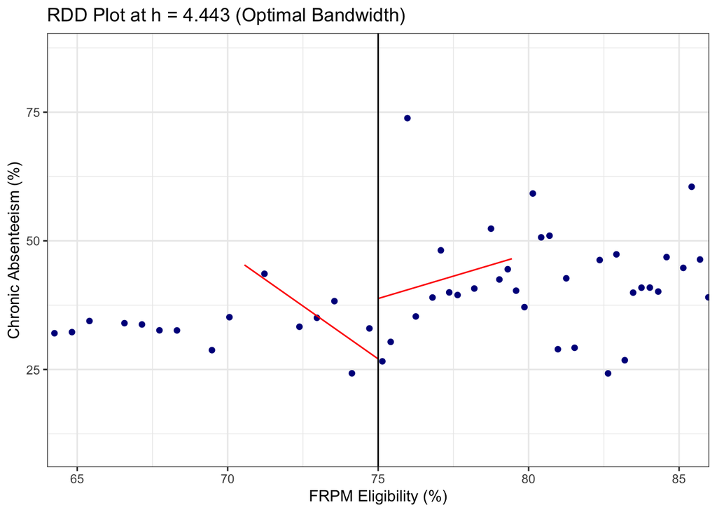

```r
library(rdrobust)

# Optimal bandwidth from rdbwselect (rounded for clarity)
rdplot(merged$chronic_absenteeism, merged$frpm_rate,
       c = 75, h = 4.443, p = 1,
       x.lim = c(65, 85),
       title = "RDD Plot at h = 4.443 (Optimal Bandwidth)",
       x.label = "FRPM Eligibility (%)",
       y.label = "Chronic Absenteeism (%)")
```

```
## [1] "Mass points detected in the running variable."
```

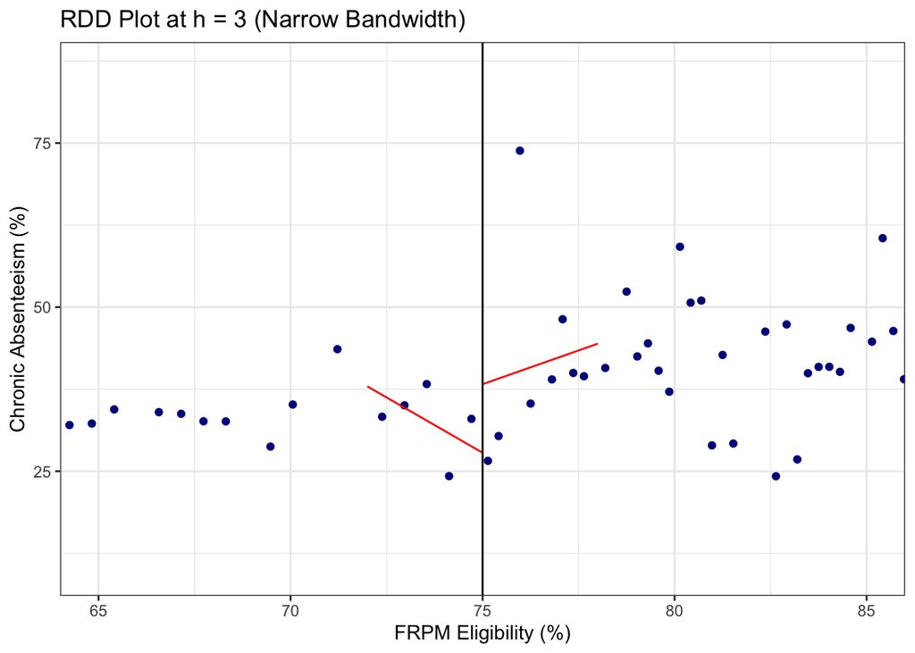

```r
# Sensitivity: Narrower
rdplot(merged$chronic_absenteeism, merged$frpm_rate,
       c = 75, h = 3, p = 1,
       x.lim = c(65, 85),
       title = "RDD Plot at h = 3 (Narrow Bandwidth)",
       x.label = "FRPM Eligibility (%)",
       y.label = "Chronic Absenteeism (%)")
```

```
## [1] "Mass points detected in the running variable."
```

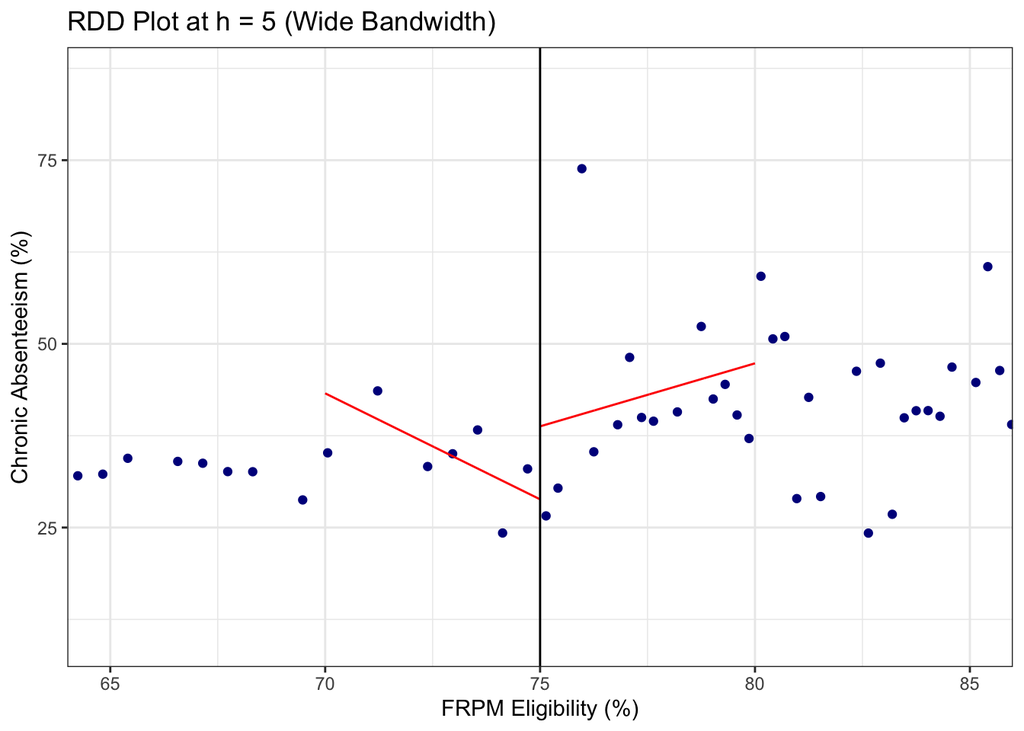

```r
# Sensitivity: Wider
rdplot(merged$chronic_absenteeism, merged$frpm_rate,
       c = 75, h = 5, p = 1,
       x.lim = c(65, 85),
       title = "RDD Plot at h = 5 (Wide Bandwidth)",
       x.label = "FRPM Eligibility (%)",
       y.label = "Chronic Absenteeism (%)")
```

```
## [1] "Mass points detected in the running variable."
```

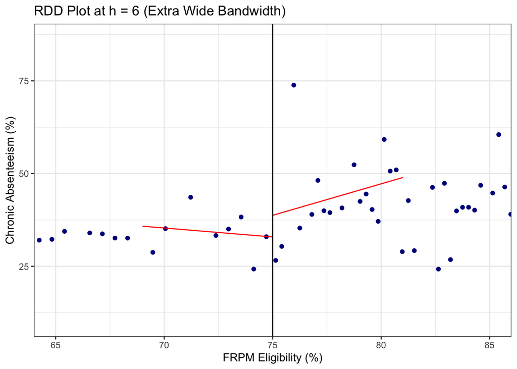

```r
# Sensitivity: Even wider
rdplot(merged$chronic_absenteeism, merged$frpm_rate,
       c = 75, h = 6, p = 1,
       x.lim = c(65, 85),
       title = "RDD Plot at h = 6 (Extra Wide Bandwidth)",
       x.label = "FRPM Eligibility (%)",
       y.label = "Chronic Absenteeism (%)")
```

# VII. Run the McCrary Density Test

**What:** Check whether schools are manipulating FRPM % to qualify.

**Why it’s important:** RDD assumes schools cannot manipulate assignment. Bunching invalidates causal claims.

**How it supports your thesis:** If there’s no manipulation, the assignment can be seen as as-good-as-random, strengthening causal identification.

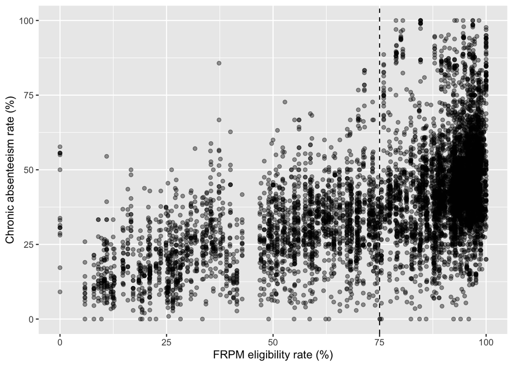

```r
library(rdrobust)
library(rddensity)

merged <- merged %>%
  mutate(
    frpm_rate = ifelse(frpm_rate <= 1, frpm_rate * 100, frpm_rate),
    running   = frpm_rate - 75,
    treated   = ifelse(frpm_rate >= 75, 1, 0)
  )

ggplot(merged, aes(frpm_rate, chronic_absenteeism)) +
  geom_point(alpha = .4) +
  geom_vline(xintercept = 75, linetype = "dashed") +
  labs(x = "FRPM eligibility rate (%)",
       y = "Chronic absenteeism rate (%)")
```

```r
library(rddensity)

# 1. McCrary density test
dens75 <- rddensity(merged$frpm_rate, c = 75)
dens75$test            # prints t_jk and p_jk
```

```
## $t_asy
## [1] NA
##
## $t_jk
## [1] -1.545891
##
## $p_asy
## [1] NA
##
## $p_jk
## [1] 0.1221309
```

```r
# 3. Density test statistics (use the right object)
dens75$test             # NOT rd75$test
```

```
## $t_asy
## [1] NA
##
## $t_jk
## [1] -1.545891
##
## $p_asy
## [1] NA
##
## $p_jk
## [1] 0.1221309
```

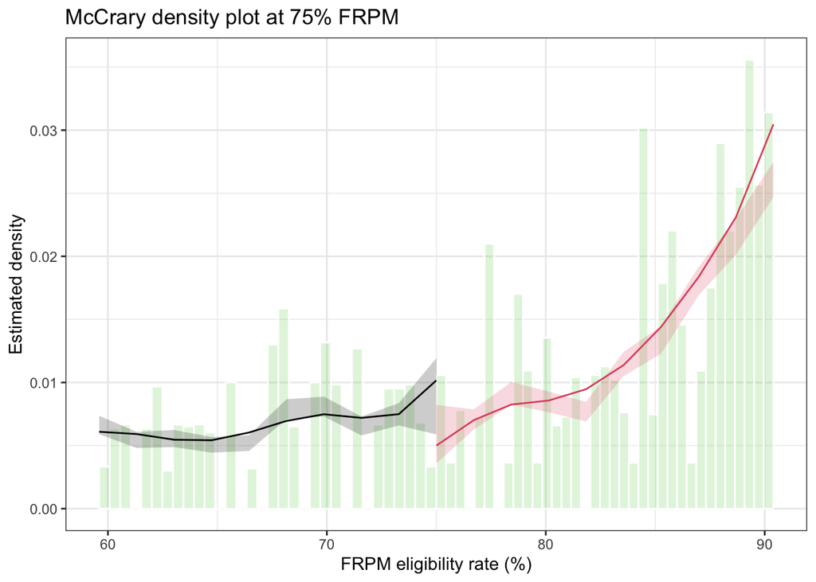

[output not shown]

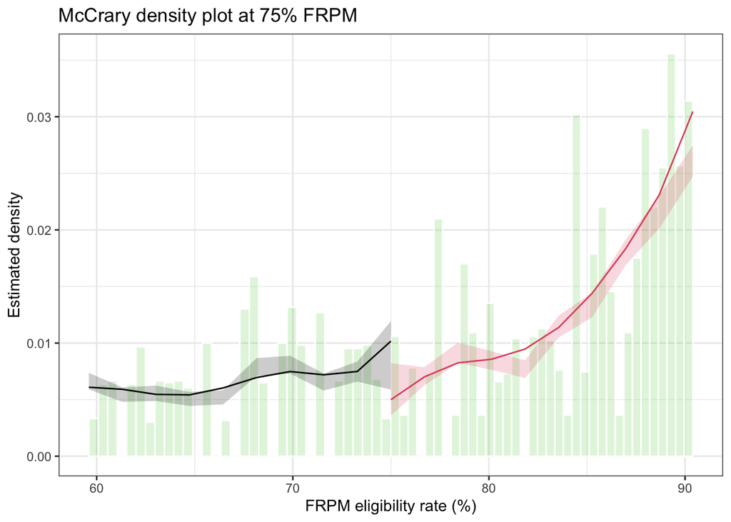

```r
# 4. McCrary density plot
# McCrary density test object
dens75 <- rddensity(merged$frpm_rate, c = 75)

# Density plot  ── rdd object first, X second ──
rdplotdensity(
  dens75,                 # ← rdd    (object returned by rddensity)
  merged$frpm_rate,       # ← X      (numeric running-variable vector)
  title  = "McCrary density plot at 75% FRPM",
  xlabel = "FRPM eligibility rate (%)",
  ylabel = "Estimated density"
)
```

# VIII. Covariate Balance Checks

**What:** Test if school characteristics (e.g., enrollment) are smooth across the cutoff.

**Why:** Ensures groups just above and below the cutoff are comparable.

**How it supports your thesis:** No discontinuity in covariates = credible causal design.

# IX. Robustness Checks

### 1. Bandwidth Sensitivity

Try different bandwidths (e.g., h = 2 to h = 6). Linear results are most credible. Avoid high-order polynomials due to overfitting.

```r
# Fit models
bw_models <- list(
  h2 = rdrobust(merged$chronic_absenteeism, merged$frpm_rate, c = 75, h = 2, p = 1),
  h3 = rdrobust(merged$chronic_absenteeism, merged$frpm_rate, c = 75, h = 3, p = 1),
  h4 = rdrobust(merged$chronic_absenteeism, merged$frpm_rate, c = 75, h = 4.443, p = 1),
  h5 = rdrobust(merged$chronic_absenteeism, merged$frpm_rate, c = 75, h = 5, p = 1),
  h6 = rdrobust(merged$chronic_absenteeism, merged$frpm_rate, c = 75, h = 6, p = 1)
)

# Create table
bw_results <- do.call(rbind, Map(function(model, h) {
  data.frame(
    Bandwidth = h,
    Coef = model$coef[1, 1],
    SE = model$se[1, 1],
    Pval = model$pv[1, 1],
    CI_Lower = model$ci[1, 1],
    CI_Upper = model$ci[1, 2]
  )
}, bw_models, c(2, 3, 4.443, 5, 6)))
knitr::kable(bw_results, digits = 3, caption = "Bandwidth Sensitivity: Local Linear RDD Estimates")
```

Bandwidth Sensitivity: Local Linear RDD Estimates

|  | Bandwidth | Coef | SE | Pval | CI_Lower | CI_Upper |
| --- | --- | --- | --- | --- | --- | --- |
| h2 | 2.000 | -2.429 | 2.811 | 0.388 | -7.939 | 3.081 |
| h3 | 3.000 | 8.075 | 2.071 | 0.000 | 4.016 | 12.134 |
| h4 | 4.443 | 10.368 | 1.734 | 0.000 | 6.969 | 13.767 |
| h5 | 5.000 | 10.175 | 1.626 | 0.000 | 6.988 | 13.361 |
| h6 | 6.000 | 8.157 | 1.441 | 0.000 | 5.332 | 10.981 |

### 2. Polynomial Order Sensitivity

```r
# Models: m7, m8, m9 (h = 4, p = 1–3)
poly_models <- list(m7, m8, m9)
poly_info <- data.frame(Poly_Order = 1:3, Bandwidth = 4)

poly_table <- do.call(rbind, Map(function(model, spec) {
  data.frame(
    Poly_Order = spec$Poly_Order,
    Coef = model$coef[1,1],
    SE = model$se[1,1],
    Pval = model$pv[1,1],
    CI_Lower = model$ci[1,1],
    CI_Upper = model$ci[1,2]
  )
}, poly_models, split(poly_info, seq(nrow(poly_info)))))

knitr::kable(poly_table, digits = 3, caption = "Polynomial Order Sensitivity at h = 4")
```

Polynomial Order Sensitivity at h = 4

| Poly_Order | Coef | SE | Pval | CI_Lower | CI_Upper |
| --- | --- | --- | --- | --- | --- |
| 1 | 9.984 | 1.862 | 0.000 | 6.334 | 13.634 |
| 2 | 1.781 | 2.766 | 0.520 | -3.639 | 7.202 |
| 3 | -13.603 | 4.368 | 0.002 | -22.164 | -5.042 |

### 3. Placebo Cutoffs (Next Step Suggestion)

Try cutoffs at 70% or 80% where no program change should occur. Null effects there will further validate your 75% results.

```r
# Placebo cutoffs at 70% and 80%
p70 <- rdrobust(merged$chronic_absenteeism, merged$frpm_rate, c = 70, h = 4, p = 1, masspoints = "adjust")
p80 <- rdrobust(merged$chronic_absenteeism, merged$frpm_rate, c = 80, h = 4, p = 1, masspoints = "adjust")

placebo_results <- do.call(rbind, Map(function(model, cutoff) {
  data.frame(
    Placebo_Cutoff = cutoff,
    Coef = model$coef[1,1],
    SE = model$se[1,1],
    Pval = model$pv[1,1],
    CI_Lower = model$ci[1,1],
    CI_Upper = model$ci[1,2]
  )
}, list(p70, p80), c(70, 80)))

knitr::kable(placebo_results, digits = 3, caption = "Placebo Cutoffs (No Expected Treatment Effect)")
```

Placebo Cutoffs (No Expected Treatment Effect)

| Placebo_Cutoff | Coef | SE | Pval | CI_Lower | CI_Upper |
| --- | --- | --- | --- | --- | --- |
| 70 | 12.845 | 1.484 | 0 | 9.936 | 15.753 |
| 80 | 11.938 | 1.447 | 0 | 9.102 | 14.773 |

### 4. Covariate Balance Across Bandwidths

# X. Final RDD Plots

Use `rdplot()` for h = 3 to 6, `p = 1`. Zoom in (65–85%) for interpretability.